# Mice expression project

Marianna Baranovskaia

10 04 2022

## Data and imports

Imports of the packages $readxl$, $dplyr$, $ggplot2$, $DESeq2$ are hidden.

```r
mice = read_xls("../data/Data_Cortex_Nuclear.xls")
```

```r
mice$Genotype = as.factor(mice$Genotype)
mice$Treatment = as.factor(mice$Treatment)
mice$Behavior = as.factor(mice$Behavior)
mice$class = as.factor(mice$class)
```

## Data description

### Description from the source

https://archive.ics.uci.edu/ml/datasets/Mice+Protein+Expression#

####Abstract

Expression levels of 77 proteins measured in the cerebral cortex of 8 classes of control and Down syndrome mice exposed to context fear conditioning, a task used to assess associative learning.

####Data Set Information

The data set consists of the expression levels of 77 proteins/protein modifications that produced detectable signals in the nuclear fraction of cortex. There are 38 control mice and 34 trisomic mice (Down syndrome), for a total of 72 mice. In the experiments, 15 measurements were registered of each protein per sample/mouse. Therefore, for control mice, there are 38x15, or 570 measurements, and for trisomic mice, there are 34x15, or 510 measurements. The dataset contains a total of 1080 measurements per protein. Each measurement can be considered as an independent sample/mouse. The eight classes of mice are described based on features such as genotype, behavior and treatment. According to genotype, mice can be control or trisomic. According to behavior, some mice have been stimulated to learn (context-shock) and others have not (shock-context) and in order to assess the effect of the drug memantine in recovering the ability to learn in trisomic mice, some mice have been injected with the drug and others have not.

####Classes

c-CS-s: control mice, stimulated to learn, injected with saline (9 mice)

c-CS-m: control mice, stimulated to learn, injected with memantine (10 mice)

c-SC-s: control mice, not stimulated to learn, injected with saline (9 mice)

c-SC-m: control mice, not stimulated to learn, injected with memantine (10 mice)

t-CS-s: trisomy mice, stimulated to learn, injected with saline (7 mice)

t-CS-m: trisomy mice, stimulated to learn, injected with memantine (9 mice)

t-SC-s: trisomy mice, not stimulated to learn, injected with saline (9 mice)

t-SC-m: trisomy mice, not stimulated to learn, injected with memantine (9 mice)

The aim is to identify subsets of proteins that are discriminant between the classes.

####Attribute Information

1 Mouse ID

2..78 Values of expression levels of 77 proteins; the names of proteins are followed by “_n” indicating that they were measured in the nuclear fraction. For example: DYRK1A_n

79 Genotype: control (c) or trisomy (t)

80 Treatment type: memantine (m) or saline (s)

81 Behavior: context-shock (CS) or shock-context (SC)

82 Class: c-CS-s, c-CS-m, c-SC-s, c-SC-m, t-CS-s, t-CS-m, t-SC-s, t-SC-m

### Descriptional statistics

Summary:

```r
summary(mice)
```

```
##    MouseID             DYRK1A_N         ITSN1_N           BDNF_N
##  Length:1080        Min.   :0.1453   Min.   :0.2454   Min.   :0.1152
##  Class :character   1st Qu.:0.2881   1st Qu.:0.4734   1st Qu.:0.2874
##  Mode  :character   Median :0.3664   Median :0.5658   Median :0.3166
##                     Mean   :0.4258   Mean   :0.6171   Mean   :0.3191
##                     3rd Qu.:0.4877   3rd Qu.:0.6980   3rd Qu.:0.3482
##                     Max.   :2.5164   Max.   :2.6027   Max.   :0.4972
##                     NA's   :3        NA's   :3        NA's   :3
##      NR1_N           NR2A_N          pAKT_N           pBRAF_N
##  Min.   :1.331   Min.   :1.738   Min.   :0.06324   Min.   :0.06404
##  1st Qu.:2.057   1st Qu.:3.156   1st Qu.:0.20575   1st Qu.:0.16459
##  Median :2.297   Median :3.761   Median :0.23118   Median :0.18230
##  Mean   :2.297   Mean   :3.844   Mean   :0.23317   Mean   :0.18185
##  3rd Qu.:2.528   3rd Qu.:4.440   3rd Qu.:0.25726   3rd Qu.:0.19742
##  Max.   :3.758   Max.   :8.483   Max.   :0.53905   Max.   :0.31707
##  NA's   :3       NA's   :3       NA's   :3         NA's   :3
##    pCAMKII_N        pCREB_N           pELK_N          pERK_N
##  Min.   :1.344   Min.   :0.1128   Min.   :0.429   Min.   :0.1492
##  1st Qu.:2.480   1st Qu.:0.1908   1st Qu.:1.204   1st Qu.:0.3374
##  Median :3.327   Median :0.2106   Median :1.356   Median :0.4436
##  Mean   :3.537   Mean   :0.2126   Mean   :1.429   Mean   :0.5459
##  3rd Qu.:4.482   3rd Qu.:0.2346   3rd Qu.:1.561   3rd Qu.:0.6633
##  Max.   :7.464   Max.   :0.3062   Max.   :6.113   Max.   :3.5667
##  NA's   :3       NA's   :3        NA's   :3       NA's   :3
##      pJNK_N            PKCA_N           pMEK_N            pNR1_N
##  Min.   :0.05211   Min.   :0.1914   Min.   :0.05682   Min.   :0.5002
##  1st Qu.:0.28124   1st Qu.:0.2818   1st Qu.:0.24429   1st Qu.:0.7435
##  Median :0.32133   Median :0.3130   Median :0.27739   Median :0.8211
##  Mean   :0.31351   Mean   :0.3179   Mean   :0.27503   Mean   :0.8258
##  3rd Qu.:0.34871   3rd Qu.:0.3523   3rd Qu.:0.30345   3rd Qu.:0.8985
##  Max.   :0.49343   Max.   :0.4740   Max.   :0.45800   Max.   :1.4082
##  NA's   :3         NA's   :3        NA's   :3         NA's   :3
##     pNR2A_N          pNR2B_N          pPKCAB_N          pRSK_N
##  Min.   :0.2813   Min.   :0.3016   Min.   :0.5678   Min.   :0.09594
##  1st Qu.:0.5903   1st Qu.:1.3813   1st Qu.:1.1683   1st Qu.:0.40414
##  Median :0.7196   Median :1.5637   Median :1.3657   Median :0.44060
##  Mean   :0.7269   Mean   :1.5620   Mean   :1.5253   Mean   :0.44285
##  3rd Qu.:0.8486   3rd Qu.:1.7485   3rd Qu.:1.8859   3rd Qu.:0.48210
##  Max.   :1.4128   Max.   :2.7240   Max.   :3.0614   Max.   :0.65096
##  NA's   :3        NA's   :3        NA's   :3        NA's   :3
```

[output cut: 113 more lines]

```
##  Min.   :0.1018   Min.   :0.5865   Control:570   Memantine:570   C/S:525
##  1st Qu.:0.1651   1st Qu.:1.0814   Ts65Dn :510   Saline   :510   S/C:555
##  Median :0.1940   Median :1.3174
##  Mean   :0.2054   Mean   :1.3378
##  3rd Qu.:0.2352   3rd Qu.:1.5858
##  Max.   :0.4139   Max.   :2.1298
##  NA's   :270
##      class
##  c-CS-m :150
##  c-SC-m :150
##  c-CS-s :135
##  c-SC-s :135
##  t-CS-m :135
##  t-SC-m :135
##  (Other):240
```

There are 1080 of the rows in the dataset.

```r
ncol(mice) - 5
```

```
## [1] 77
```

5 columns describe nominative variables (MouseID, Genotype, Treatment, Behavior, class) and 77 columns contains numeric variables.

NA’s:

```r
apply(X = is.na(mice), MARGIN = 2, FUN = sum)
```

```
##         MouseID        DYRK1A_N         ITSN1_N          BDNF_N           NR1_N
##               0               3               3               3               3
##          NR2A_N          pAKT_N         pBRAF_N       pCAMKII_N         pCREB_N
##               3               3               3               3               3
##          pELK_N          pERK_N          pJNK_N          PKCA_N          pMEK_N
##               3               3               3               3               3
##          pNR1_N         pNR2A_N         pNR2B_N        pPKCAB_N          pRSK_N
##               3               3               3               3               3
##           AKT_N          BRAF_N        CAMKII_N          CREB_N           ELK_N
##               3               3               3               3              18
##           ERK_N         GSK3B_N           JNK_N           MEK_N          TRKA_N
##               3               3               3               7               3
##           RSK_N           APP_N      Bcatenin_N          SOD1_N          MTOR_N
##               3               3              18               3               3
##           P38_N         pMTOR_N         DSCR1_N         AMPKA_N          NR2B_N
##               3               3               3               3               3
##         pNUMB_N        RAPTOR_N         TIAM1_N        pP70S6_N          NUMB_N
##               3               3               3               3               0
##         P70S6_N        pGSK3B_N         pPKCG_N          CDK5_N            S6_N
##               0               0               0               0               0
##        ADARB1_N    AcetylH3K9_N          RRP1_N           BAX_N           ARC_N
##               0               0               0               0               0
##         ERBB4_N          nNOS_N           Tau_N          GFAP_N         GluR3_N
##               0               0               0               0               0
##         GluR4_N          IL1B_N         P3525_N        pCASP9_N         PSD95_N
##               0               0               0               0               0
##          SNCA_N     Ubiquitin_N pGSK3B_Tyr216_N           SHH_N           BAD_N
##               0               0               0               0             213
##          BCL2_N           pS6_N         pCFOS_N           SYP_N       H3AcK18_N
##             285               0              75               0             180
##          EGR1_N        H3MeK4_N          CaNA_N        Genotype       Treatment
##             210             270               0               0               0
##        Behavior           class
##               0               0
```

```r
print(max(apply(X = is.na(mice), MARGIN = 2, FUN = sum)))
```

```
## [1] 285
```

```r
print(1080-max(apply(X = is.na(mice), MARGIN = 2, FUN = sum)))
```

```
## [1] 795
```

Before the analysis I have replaced NA’s in the columns for the column mean values.

```r
mice[2:78] <- data.frame(sapply(mice[2:78], function(x) ifelse(is.na(x), mean(x, na.rm = TRUE), x)))
apply(X = is.na(mice), MARGIN = 2, FUN = sum)
```

```
##         MouseID        DYRK1A_N         ITSN1_N          BDNF_N           NR1_N
##               0               0               0               0               0
##          NR2A_N          pAKT_N         pBRAF_N       pCAMKII_N         pCREB_N
##               0               0               0               0               0
##          pELK_N          pERK_N          pJNK_N          PKCA_N          pMEK_N
##               0               0               0               0               0
##          pNR1_N         pNR2A_N         pNR2B_N        pPKCAB_N          pRSK_N
##               0               0               0               0               0
##           AKT_N          BRAF_N        CAMKII_N          CREB_N           ELK_N
##               0               0               0               0               0
##           ERK_N         GSK3B_N           JNK_N           MEK_N          TRKA_N
##               0               0               0               0               0
##           RSK_N           APP_N      Bcatenin_N          SOD1_N          MTOR_N
##               0               0               0               0               0
##           P38_N         pMTOR_N         DSCR1_N         AMPKA_N          NR2B_N
##               0               0               0               0               0
##         pNUMB_N        RAPTOR_N         TIAM1_N        pP70S6_N          NUMB_N
##               0               0               0               0               0
##         P70S6_N        pGSK3B_N         pPKCG_N          CDK5_N            S6_N
##               0               0               0               0               0
##        ADARB1_N    AcetylH3K9_N          RRP1_N           BAX_N           ARC_N
##               0               0               0               0               0
##         ERBB4_N          nNOS_N           Tau_N          GFAP_N         GluR3_N
##               0               0               0               0               0
##         GluR4_N          IL1B_N         P3525_N        pCASP9_N         PSD95_N
##               0               0               0               0               0
##          SNCA_N     Ubiquitin_N pGSK3B_Tyr216_N           SHH_N           BAD_N
##               0               0               0               0               0
##          BCL2_N           pS6_N         pCFOS_N           SYP_N       H3AcK18_N
##               0               0               0               0               0
##          EGR1_N        H3MeK4_N          CaNA_N        Genotype       Treatment
##               0               0               0               0               0
##        Behavior           class
##               0               0
```

No NA now

## Does the BDNF_N expression differ dependent on the class?

```r
shapiro.test(mice$BDNF_N)
```

```
##
##  Shapiro-Wilk normality test
##
## data:  mice$BDNF_N
## W = 0.99255, p-value = 2.939e-05
```

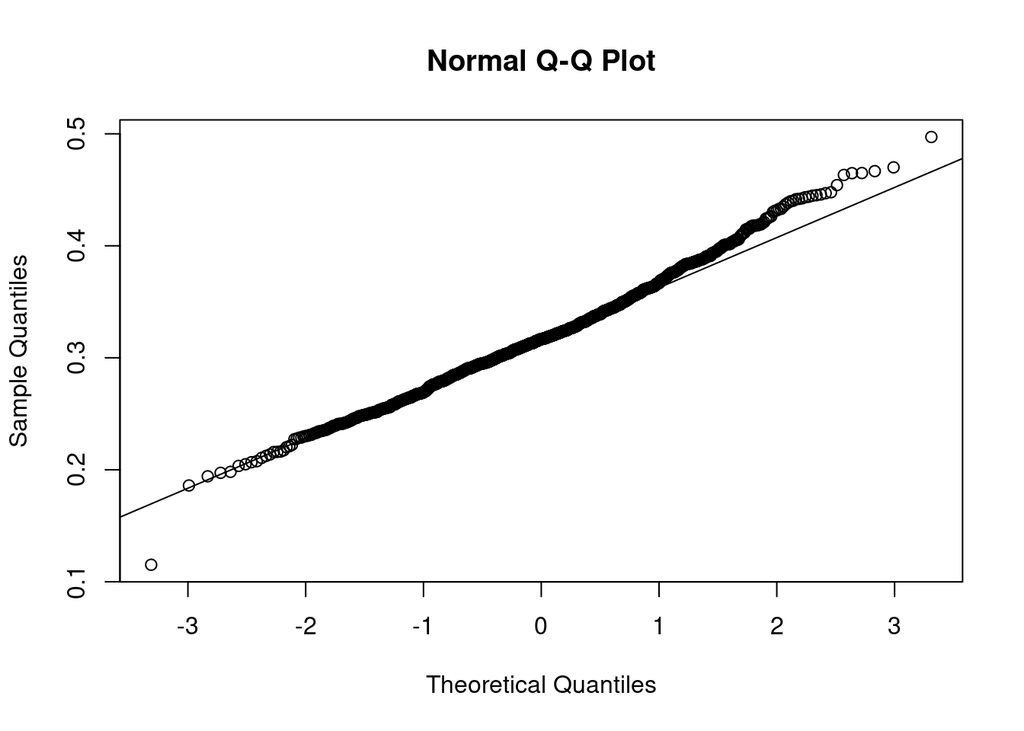

```r
qqnorm(mice$BDNF_N)
qqline(mice$BDNF_N)
```

According to the Shapiro-Wilk test, the data are not distributed normally (p-value is less than 0.05 and H0 (the distribution is normal) should be rejected). But according to the QQ-plot we can see some outliers but in general the points are near to the theoretical line. Let’s try to do ANOVA, maybe it will be OK.

One-way ANOVA

```r
oneway_BDNF_N <- aov(BDNF_N ~ class, data = mice)
summary(oneway_BDNF_N)
```

```
##               Df Sum Sq Mean Sq F value Pr(>F)
## class          7 0.2877 0.04110   18.86 <2e-16 ***
## Residuals   1072 2.3363 0.00218
## ---
## Signif. codes:  0 '***' 0.001 '**' 0.01 '*' 0.05 '.' 0.1 ' ' 1
```

P-value is <2e-16 (less than 0.05), so we can reject the null hypothesis (that there are no differences in the expression in different classes).

## Linear model to predict the ERBB4_N expression depending on the other proteins level.

The big one:

```r
lm_ERBB4_N_all <- lm(ERBB4_N ~ DYRK1A_N + ITSN1_N + BDNF_N + NR1_N + NR2A_N + pAKT_N + pBRAF_N + pCAMKII_N + pCREB_N + pELK_N + pERK_N + pJNK_N + PKCA_N + pMEK_N + pNR1_N + pNR2A_N + pNR2B_N + pPKCAB_N + pRSK_N + AKT_N + BRAF_N + CAMKII_N + CREB_N + ELK_N + ERK_N + GSK3B_N + JNK_N + MEK_N + TRKA_N + RSK_N + APP_N + Bcatenin_N + SOD1_N + MTOR_N + P38_N + pMTOR_N + DSCR1_N + AMPKA_N + NR2B_N + pNUMB_N + RAPTOR_N + TIAM1_N + pP70S6_N + NUMB_N + P70S6_N + pGSK3B_N + pPKCG_N + CDK5_N + S6_N + ADARB1_N + AcetylH3K9_N + RRP1_N + BAX_N + ARC_N + nNOS_N + Tau_N + GFAP_N + GluR3_N + GluR4_N + IL1B_N + P3525_N + pCASP9_N + PSD95_N + SNCA_N + Ubiquitin_N + pGSK3B_Tyr216_N + SHH_N + BAD_N + BCL2_N + pS6_N + pCFOS_N + SYP_N + H3AcK18_N + EGR1_N + H3MeK4_N + CaNA_N, mice)

summary(lm_ERBB4_N_all)
```

```
##
## Call:
## lm(formula = ERBB4_N ~ DYRK1A_N + ITSN1_N + BDNF_N + NR1_N +
##     NR2A_N + pAKT_N + pBRAF_N + pCAMKII_N + pCREB_N + pELK_N +
##     pERK_N + pJNK_N + PKCA_N + pMEK_N + pNR1_N + pNR2A_N + pNR2B_N +
##     pPKCAB_N + pRSK_N + AKT_N + BRAF_N + CAMKII_N + CREB_N +
##     ELK_N + ERK_N + GSK3B_N + JNK_N + MEK_N + TRKA_N + RSK_N +
##     APP_N + Bcatenin_N + SOD1_N + MTOR_N + P38_N + pMTOR_N +
##     DSCR1_N + AMPKA_N + NR2B_N + pNUMB_N + RAPTOR_N + TIAM1_N +
##     pP70S6_N + NUMB_N + P70S6_N + pGSK3B_N + pPKCG_N + CDK5_N +
##     S6_N + ADARB1_N + AcetylH3K9_N + RRP1_N + BAX_N + ARC_N +
##     nNOS_N + Tau_N + GFAP_N + GluR3_N + GluR4_N + IL1B_N + P3525_N +
##     pCASP9_N + PSD95_N + SNCA_N + Ubiquitin_N + pGSK3B_Tyr216_N +
##     SHH_N + BAD_N + BCL2_N + pS6_N + pCFOS_N + SYP_N + H3AcK18_N +
##     EGR1_N + H3MeK4_N + CaNA_N, data = mice)
##
## Residuals:
##       Min        1Q    Median        3Q       Max
## -0.025580 -0.003812 -0.000052  0.003678  0.038116
##
## Coefficients: (1 not defined because of singularities)
##                   Estimate Std. Error t value Pr(>|t|)
## (Intercept)      2.630e-02  5.788e-03   4.544 6.20e-06 ***
## DYRK1A_N        -8.203e-03  5.464e-03  -1.501 0.133624
## ITSN1_N          1.318e-02  5.959e-03   2.212 0.027188 *
## BDNF_N          -2.766e-03  1.433e-02  -0.193 0.846986
## NR1_N           -6.498e-03  3.835e-03  -1.694 0.090518 .
## NR2A_N           2.854e-04  9.777e-04   0.292 0.770443
## pAKT_N           3.145e-02  1.457e-02   2.158 0.031176 *
## pBRAF_N         -4.655e-02  2.225e-02  -2.092 0.036689 *
## pCAMKII_N       -1.431e-04  4.629e-04  -0.309 0.757304
## pCREB_N         -3.836e-02  2.037e-02  -1.883 0.059989 .
## pELK_N          -6.982e-04  9.729e-04  -0.718 0.473100
## pERK_N          -1.918e-03  2.649e-03  -0.724 0.469174
## pJNK_N          -3.444e-02  1.677e-02  -2.054 0.040265 *
## PKCA_N           4.444e-02  1.566e-02   2.837 0.004639 **
## pMEK_N          -8.285e-03  1.636e-02  -0.506 0.612700
## pNR1_N          -1.967e-02  9.012e-03  -2.183 0.029259 *
## pNR2A_N          4.345e-03  4.438e-03   0.979 0.327840
## pNR2B_N          3.988e-03  3.813e-03   1.046 0.295953
```

[output cut: 50 more lines]

```
## BAD_N           -3.172e-02  1.623e-02  -1.955 0.050912 .
## BCL2_N           8.103e-03  1.487e-02   0.545 0.586023
## pS6_N                   NA         NA      NA       NA
## pCFOS_N         -4.762e-02  1.673e-02  -2.846 0.004515 **
## SYP_N            2.090e-02  6.523e-03   3.204 0.001399 **
## H3AcK18_N       -1.551e-05  7.375e-03  -0.002 0.998323
## EGR1_N           1.699e-02  1.111e-02   1.529 0.126487
## H3MeK4_N         6.906e-03  9.944e-03   0.695 0.487489
## CaNA_N          -6.700e-03  2.453e-03  -2.732 0.006410 **
## ---
## Signif. codes:  0 '***' 0.001 '**' 0.01 '*' 0.05 '.' 0.1 ' ' 1
##
## Residual standard error: 0.006686 on 1004 degrees of freedom
## Multiple R-squared:  0.8169, Adjusted R-squared:  0.8032
## F-statistic: 59.71 on 75 and 1004 DF,  p-value: < 2.2e-16
```

Adjusted R-squared is 0.8032, not very good result. There are 76 of predictors and this model seems to be “over-predicted” because it is highly likely that only several predictors describe the most variance. It seems to be that we need to reduce the dimensions of the model.

## PCA

Not today =)